# Optimal Control of Individual-Based Disease Models

Noam Ross

July 25, 2015

## Introduction

A central challenge in disease ecology is developing effective management strategies to control harmful diseases and limit their damage to wildlife, human health, and ecosystem services. Using models of the dynamics of hosts and disease, this can be formulated as an economic optimization problem: how to maximize the benefits of a strategy, or how to minimize the costs of meeting a disease control goal.

Disease management may be considered an economic problem: Given limited resources, how to best manage disease to minimize impacts? Or, conversely, given management targets, how to best limit the cost of disease control? Research addressing such questions - economic epidemiology - is a growing field (Brandeau *et al.* 2003; Rowthorn *et al.* 2009), though the literature to on the economics of wildlife disease is more limited] (Bicknell1999; Horan & Wolf 2005; Fenichel2010; Horie *et al.* 2013). The bioeconomics of invasive species management is more broadly explored (Sharov & Liebhold 1998; Carrasco *et al.* 2010; Haight & Polasky 2010; Epanchin-Niell *et al.* 2012), and has many close parallels with the economics of disease management

Individual-based models (IBMs, also called agent-based models) simulate systems based on the behavior and properties of individuals, rather than the population as a whole. IBMs can simulate system behavior arising from interactions difficult to describe in aggregate, including network contact structure, spatial heterogeneity, variation in individual traits, all of which can affect disease transmission. These individual behaviors and interactions in such models result in emergent population-level dynamics that often can not be expressed as a closed-form set of equations at the population level without making strong assumptions about the distribution of individuals. (Grimm & Railsback 2005)

Determining optimal control approaches using IBMs is more challenging. In the absence of closed-form equations of overall system behavior, one can not derive optimal control decisions analytically. IBMs also suffer from “the curse of dimensionality”: high dimensionality results in very large state space that can not be explored thoroughly.

One approach to optimal controlling using IBMs has been to apply control analytical techniques to reduced-form models. The optimization problem can be solved on a set of ordinary differential equations that represent an approximation of the IBM. Using this approach, a mean-field approximation of an IBM can be used to determine an optimal control path when the IBM is homogenous, but ay perform poorly under when the underlying system is heterogenous (Federico *et al.* 2013). Another approach is to generate population-level models with non-mechanistic equations that approximate IBM behavior. Such methods can yield better results than mean-field models. However, the applicability of these adjusted models is limited to the the range over which they were parameterized, and model parameters are difficult to interpret [Oremland 2015].

## Equation-free modeling

Equation-free (EF), or multi-scale, modeling (Armaou et al. (2004), but see Kevrekidis & Samaey (2009) for review) is a method for capturing and analyzing population-scale dynamics of individual-based models while bypassing the deriving population-scale equations, which exist conceptually but often can not be derived. It has been used in a variety of applications, including evolution, movement ecology and epidemiology [Cisternas et al. (2004); (Erban *et al.* 2006; Gross2008a; Raghib2010; Williams *et al.* 2015)

In EF modeling, the population-scale dynamics are estimated using bursts of the IBM. At each time step, a “lifting” operator maps the population-scale state to a distribution of possible individual-scale states. Each of these instances of the individual-based model is simulated for a short burst of time, then they are collapsed back to a single population-level state with a “restricting function.”

Some information about the IBM state is lost by restriction and generated by lifting. Thus, these EF is another form of model reduction, albeit one that offers alternatives to mean-field and other approximations. Lifting and restriction operators may be chosen to capture the important heterogeneities represented in the IBM and relevant to the problem at hand. While these functions must be chosen with care, the rules governing the IBM may be a “black box” within the EF framework.

The system dynamics may be simulated by the lift-simulate-restrict cycle alone. However, it is computationally advantageous to use in conjunction with a projection step. In this approach, rather than simulating for an entire time-step, the simulation is run for a fraction of a time step to obtain an estimate the time derivative of the population-scale system. The population-scale state is then projected forward using a differential equation solver.

## Optimal control

Clark (1990) describes in detail the methods of deriving an optimal control path for dynamical ecological systems, which I briefly review here. The optimal path of a control variable over time $(h(t))$ is that which maximizes the integral of a profit function $\pi(x, h, t)$ over a time period $(T_0, T)$, subject to the dynamics of the system state $x$, the dynamics of which are governed by $\frac{dx}{dt} = f(x, h, t)$. That is,

$\max_{h >= 0} \int_{T_0=0}^T \pi(x, h, t) \, dt\, \text{ subject to } \frac{dx}{dt} = f(x, h, t)$

Where $x$ and $h$ may be vectors representing the system state and control variables.

Various numerical methods can be used to find the optimal control path. Where $f(x, t, h)$ has a closed-form, the control path can be derived analytically by maximizing *Hamiltonian* ($\mathcal H$) equation:

$\mathcal H = \pi(x, h, t) + \eta f(x, h, t)$

Here $\eta$ is the “shadow value” of the system state $x$, and represents the per-unit value of the contribution $x$ to *future* profit. The dynamics of $\eta$ are governed by the adjoint equation:

$\frac{d\eta}{dt} = - \frac{\partial \mathcal H}{\partial dx} = -\frac{\partial \pi(\cdot)}{\partial x} + \eta(t) \frac{\partial f(\cdot)}{\partial x}$

To find the optimal path for the control $h$, we solve for the maximum of $\mathcal H$ over the time period $(T_0, T)$. The local optimum of $\mathcal H$ can be determined by finding $h$ where ${\partial \mathcal H}{\partial dh} = 0$.

The resulting solution for $h(t)$ is dependent on the initial values of of $x$ and $\eta$, $(x_0, \eta_0)$. In many systems, some or all of these values are unknown. In many cases the terminal values ($x_T$) are constraints on the problem. In the case of unconstrained problems, the optimal path is that that ends with $\eta_T = 0$. In these cases, initial conditions can be determined numerically using a boundary problem solver.

## A framework equation-free optimal control

The method described above requires a closed-form expression of $dx/ft = f(x, h, t)$ in order to derive the optimal control path $h(t)$. When the system of interest is modeled using an IBM, this population-level expression may not be available, even while our objective function $\pi(\cdot)$ is expressed in terms of population-level state. The EF framework can be used to calculate an optimal control path for an IBM, however, by numerically estimating $f(\cdot)$ and the values derived from it.

In EF optimal control, $f(\cdot) = dx/dt, d\eta/dt$, and $h_{opt}(t)$, are estimated numerically at each time step in a differential equation solver. Starting at $t = T_0$, with initial conditions $x_0$ and $\eta_0$, $f(\cdot)$ is estimated numerically under an initial guess for $h(t)$ using a short burst of the lifting-simulation-restriction cycle. Using this value of $f(\cdot)$, the value of $\mathcal H$ is calculated. Using a numerical optimizer, this is repeated with refined values of $h(t)$ until a value that maximizes $\mathcal H$, $h_{opt}(t)$ is found.

To determine $d\eta / dt$, an value for $\frac{\partial f(\cdot)}{\partial x}$ is required. This is estimated by perturbing $x$ by a small value, $\Delta x$, calculating $f(x + \Delta x, h_{opt}, t)$ and estimating $\frac{\partial f(\cdot)}{\partial x}$ by finite differencing.

$dx/dt$ and $d\eta/dt$ can then be passed to a differential equation solver to project the forward system in time and calculate the paths of $x(t), (t)%, and $h(t)$. As in the optimal control scenario above, a boundary problem solver can then be used to determine initial values for $x_0$ and $\eta_0$ based on the constraints of the problem.

## Model system

I demonstrate the method described above on a problem of maintaining a wildlife population in the face of an invading disease. The model is a host-pathogen system similar to the macroparasite model of Anderson & May (1978), where individuals can host multiple pathogens of the same type, and suffer increased mortality with greater infection load. The primary differences are the separation of birth and death processes and the influx of infectious particles from outside the system.

The control problem is to maximize net benefit of ecosystem services derived from the wildlife population by costly control measures reducing the influx of disease. This is a problem faced in numerous systems, such as the conservation of frog populations in the face of *Batrachochytrium dendrobatidis* (chytrid fungus), tanoak populations being invaded by *Phytophthora ramorum* (sudden oak death), or bat populations at risk from *Geomyces destructans* (white nose syndrome). In each of these systems, invasion of the disease reduces local populations of hosts, but local populations can be protected from arrival of new disease with some efficacy by various measures, such as education, quarantine, disinfection, and culling nearby infected populations.

A deterministic, mean-field, continuous model of this system can be represented by a small set od ODEs. In this model, the host population $N$ increases via density-dependent reproduction ($rN(1-N/K)$) and decreases via a constant intrinsic mortality rate ($d$), as well as additional mortality $\alpha$ for each infection $P$ in a host:

$\frac{dN}{dt} = r N (1 - N/K) - \alpha P - d N$

The pathogen population $P$ grows via a spore production and estabilishment rate $lambda$ and via density-dependent contact between hosts, totaling $\lambda P N$. $P$ decreases via pathogen mortality ($\mu P$), background host mortality ($dP$), and mortality due to the disease, which affects the most-infected hosts most $alpha (P + P/N)$. The form of this term depends on the assumption of a random (Poisson) distribution of pathogens among hosts (Anderson & May 1978). Finally, additional parasites enter the system via external propagule pressure $\lambda_{ex}$. $\lambda_{ex}$ may be reduced by control effort $h(t)$, which reduces propagule pressure by a factor of $e^{h(t)}$.

$\frac{dP}{dt} = \lambda P N - \mu P - d P - \alpha P - \alpha P^2/N + e^{-h} N \lambda_{ex}$

This model assumes (1) a large population size adequately represented by continuous variables, (2) a constant distribution of parasites among individuals, and (3) no stochastic processes.

The individual-based version of this model relaxes these assumptions. In the IBM, the state of the system is represented as a set of individual hosts, each with a discrete number of infections. Births, deaths, new infections and loss of infections (recovery) in each individual $i$ with number of infections $j_i$, occur stochastically according to rates $r$:

$\begin{aligned} r_{i, \, birth} &= \max \left\{ r(1-N/K), \, 0 \right\} \\ r_{i, \, death} &= \alpha j_i + d \\ r_{i, \, infection} &= \lambda \sum_{n=1}^N j_n + \lambda_{ex} e^{h(t)} \\ r_{i, \, recovery} &= \mu j_i \end{aligned}$

This stochastic process occurs in continuous time, implemented via Gillespie’s (1976) stochastic simulation algorithm (SSA).

Table 1 shows the model parameters used for all models in this paper.

Parameters for the host-pathogen models and management problem

| Parameter | Symbol | Value |
| --- | --- | --- |
| birth rate | $r$ | 0.5 |
| carrying capacity | K | 1000 |
| intrinsic host mortality rate | $d$ | 0.01 |
| intrinsic pathogen mortality rate | $ | 0.01 |
| additional mortality per infection | $\alpha$ | 0.1 |
| contact rate | $\lambda$ | 2e-04 |
| external spore arrival rate | $\lambda_{ex}$ | 0.05 |
| initial host population | $N_0$ | 1000 |
| initial pathogen population | $P_0$ | 0 |
| benefit per host per unit time | $v$ | 500 |
| cost of control per unit time | $c$ | 2000 |
| time period | $T$ | 40 |

### Management problem

For the management problem, the objective function is to is to maximize ecosystem service provided by the host population, $v$, per host per unit time. The control variable, $h$, represents of reducing the arrival rate of new infections and each unit of effort has a cost $c$. Thus, the optimization problem is to maximize the net benefits over the course of a time period $T$, subject to the dynamics of the system.

$\max_{h >= 0} \int_{t=0}^T \pi(x,h,t), dt\, \text{ s.t. } \frac{dx}{xt} = f(x, h, t)$

For the mean-field ODE system, one can derive the Hamiltonian equation based on this problem, which must be optimized for all time points, the shadow values $\nu_1$ and $\nu_2$, and an expression that can be solved for $h(t)$:

$\begin{align} \mathcal{H} &= vN - ch + \\ &\nu_1 \left( rN(1 - N/K) - \alpha P - d N \right) + \\ &\nu_2 \left(\lambda P N - \mu P - d P - \alpha P - \alpha (P^2)/N + e^{-h} N \lambda_{ex} \right) \\ \frac{d\nu_1}{dt} &= -v - \nu_1 \left(r - d - 2r \frac{N}{K}\right) - \nu_2 \left(\lambda P + \alpha \frac{P^2}{N^2} + e^{-h} \lambda_{ex} \right) + \delta \nu_1 \\ \frac{d\nu_2}{dt} &= \nu_1 \alpha - \nu_2 \left(\lambda N - \mu - d - \alpha - \frac{2 \alpha P}{N} \right) + \delta \nu_2 \\ 0 &= h \left( -c - \nu_2 e^{-h} N * \lambda_{ex} \right) \end{align}$

### Numerical approach

To solve the management problem under the IBM system, I use the equation-free approach described above. As in this case, the Hamiltonian can only be expressed in terms of the estimated values for $f(\cdot)$. I use dot notation $(\dot P \approx dP/dt)$ to denote derivatives estimated the EF lift-simulate-restrict cycle:

$\begin{align} \bar{\mathcal{H}} &= vN - ch + \nu_1 \dot N + \nu_2 \dot P \\ \dot \nu_1 &= -v - \nu_1 \frac{d \dot N}{dN} - \nu_2 \frac{d \dot P}{dN} \\ \dot \nu_2 &= -v - \nu_1 \frac{d \dot N}{dP} - \nu_2 \frac{d \dot P}{dP} \end{align}$

I use a lifting function that’s randomly distributes $P$ infections across $N$ individuals (a Poisson Process). For the reverse (restriction), I simply sum the total host and parasite populations. When mapping from non-integer macro-states, simulations are run with all combinations of macro-variables rounded up and down, and the overall results is determined by a weighted average of these simulations.

While the EF framework can be used on “black box” simulators, taking advantage of some properties of the individual-based model can improve computational efficiency and performance of the method. In this case, I do so in two ways. First, as the IBM uses the Gillespie simulation algorithm, I use a single variable-time “Gillespie” micro-step rather than a fixed-period micro-step. This allows me to estimate $\dot N$ and $\dot P$ directly at each time step $t$, avoiding the error incurred with a fixed micro-step which would estimate these values at a time slightly offset from $t$. Second, rather than rather than estimating $d \dot X /dX$ terms above by perturbing the system after solving for $\bar h_{opt}$, I take advantage of the mapping between continuous population states at the macro-level and discrete counts at the micro-level. When lifting a continuous macro-level to create an ensemble of random micro-level states, some will have populations rounded down from the continuous level, and some rounded up. The difference in $\dot X$ between these instances of the simulation is used to determine $d \dot X/ dX$ without additional simulations.

The system is integrated using a simple forward Euler integrator and then a boundary problem solved via a shooting algorithm. More sophisticated and computationally intense integrators, such as Runge-Kutta and Adams-Bashford may be used for greater accuracy (Williams *et al.* 2015).

## Results

Figure 1 shows trajectories for the system in the absence of control, simulated in three ways: the mean-field ODE system, 100 simulations of the IBM, and the expected trajectory as estimated by the equation-free model with 10000 simulations per step.

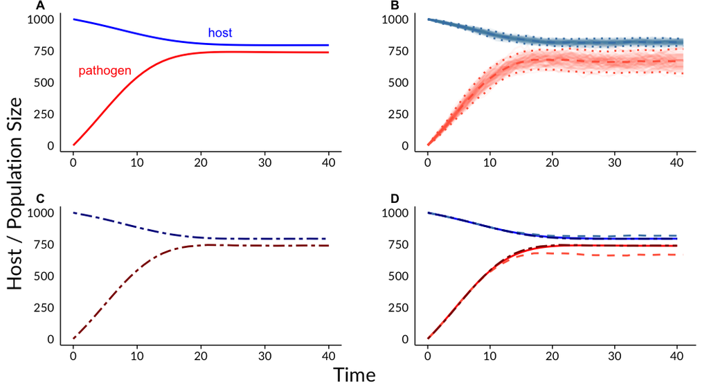

The general trajectory of the system is similar in all cases. In the absence of control, the disease invades the system rapidly. This reduces the population via increased overall mortality rate for hosts, and the system reaches a stable equilibrium with a suppressed host population endemic infections.

While the trajectory of all three models is similar, the EF value is closer to the mean-field ODE than the average of the IBM trajectories. This reflects the fact that both analytical process of deriving the ODE from Anderson & May (1978), and the choice of lift/restrict functions in the EF model make similar assumptions: that the distribution of infections follows a Poisson distribution. The IBM simulation has a lower requilibrium pathogen population and a slightly higher host population. This difference of the complete IBM reflects some deviation from the Poisson assumption. Some of the deviation also be attributable to Jensen’s (1906) inequality.

## Discussion

### Methodological issues

This IBM is relatively simple. It lacks several features that are trivial to incorporate into an IBM but challenging to represent in closed-form solutions, such as individual variation in traits or heterogenity in the host contact structure.

- Importance of lifting, restriction functions
- Sensitivity to number of simulations and micro-step size, integration algorithms
- Boundary conditions. ODE can provide guidance in values.

### Broad implications

1.Anderson, R. & May, R. (1978). Regulation and stability of host-parasite population interactions: I. Regulatory processes. *The Journal of Animal Ecology*, 47, 219–247.

2.Armaou, A., I. Siettos, C. & G. Kevrekidis, I. (2004). Time-steppers and“coarse” control of distributed microscopic processes. *International Journal of Robust and Nonlinear Control*, 14, 89–111.

3.Brandeau, M.L., Zaric, G.S. & Richter, A. (2003). Resource allocation for control of infectious diseases in multiple independent populations: beyond cost-effectiveness analysis. *Journal of Health Economics*, 22, 575–598.

4.Carrasco, L.R., Baker, R., Macleod, a, Knight, J.D. & Mumford, J.D. (2010). Optimal and robust control of invasive alien species spreading in homogeneous landscapes. *Journal of the Royal Society, Interface / the Royal Society*, 7, 529–40.

5.Cisternas, J., Gear, C.W., Levin, S. & Kevrekidis, I.G. (2004). Equation-free modelling of evolving diseases: coarse-grained computations with individual-based models. *Proceedings of the Royal Society A: Mathematical, Physical and Engineering Sciences*, 460, 2761–2779.

6.Clark, C.W. (1990). *Mathematical Bioeconomics: The Optimal Management of Renewable Resources*. 2nd edn. Wiley; Sons, New York, NY.

7.Epanchin-Niell, R.S., Haight, R.G., Berec, L., Kean, J.M. & Liebhold, A.M. (2012). Optimal surveillance and eradication of invasive species in heterogeneous landscapes. *Ecology letters*, 15, 803–12.

8.Erban, R., Kevrekidis, I.G. & Othmer, H.G. (2006). An equation-free computational approach for extracting population-level behavior from individual-based models of biological dispersal. *Physica D: Nonlinear Phenomena*, 215, 1–24.

9.Federico, P., Gross, L.J., Lenhart, S. & Ryan, D. (2013). Optimal control in individual-based models: implications from aggregated methods. *The American Naturalist*, 181, 64–77.

10.Fenichel, E.P., Horan, R.D. & Hickling, G.J. (2010). Management of infectious wildlife diseases: bridging conventional and bioeconomic approaches. *Ecological Applications*, 20, 903–914.

11.Gillespie, D.T. (1976). A general method for numerically simulating the stochastic time evolution of coupled chemical reactions. *Journal of Computational Physics*, 22, 403–434.

12.Grimm, V. & Railsback, S. (2005). *Individual-based Modeling and Ecology*.

13.Haight, R.G. & Polasky, S. (2010). Optimal control of an invasive species with imperfect information about the level of infestation. *Resource and Energy Economics*, 32, 519–533.

14.Horan, R.D. & Wolf, C.A. (2005). The Economics of Managing Infectious Wildlife Disease. *American Journal of Agricultural Economics*, 87, 537–551.

15.Horie, T., Haight, R.G., Homans, F.R. & Venette, R.C. (2013). Optimal strategies for the surveillance and control of forest pathogens: A case study with oak wilt. *Ecological Economics*, 86, 78–85.

16.Jensen, J.L.W.V. (1906). Sur les fonctions convexes et les inégalités entre les valeurs moyennes. *Acta Mathematica*, 30, 175–193.

17.Kevrekidis, I.G. & Samaey, G. (2009). Equation-free multiscale computation: algorithms and applications. *Annual review of physical chemistry*, 60, 321–44.

18.Powell, J.A. & Bentz, B.J. (2009). Connecting phenological predictions with population growth rates for mountain pine beetle, an outbreak insect. *Landscape Ecology*, 24, 657–672.

19.Rowthorn, R.E., Laxminarayan, R. & Gilligan, C. a. (2009). Optimal control of epidemics in metapopulations. *Journal of the Royal Society, Interface / the Royal Society*, 6, 1135–44.

20.Sharov, A.A. & Liebhold, A.M. (1998). Bioeconomics of Managing the Spread of Exotic Pest Species with Barrier Zones. *Ecological Applications*, 8, 833–845.

21.Williams, M.O., Proctor, J.L. & Kutz, J.N. (2015). Modeling disease transmission near eradication: An equation free approach. *Physica D: Nonlinear Phenomena*, 290, 44–56.